# RDD on unemployment entry sample

# 5. Medium-term effects: up to 3 years after entry into unemployment

## 5.1 cumulative quarters in employment (Q1–Q12)

For each quarter endpoint q (Q1 = m3, Q2 = m6, …, Q12 = m36), the outcome is the **cumulative number of months** spent in a given employment state from m1 through the end of quarter q. This gives a stock measure of how much time eligible workers spent in each state over the medium term.

Four outcomes:

- **Cum. months in any employment** (`cum_work`): reuses the pre-built `cum_work_m{h}` columns
- **Cum. months in private sector** (`cum_employee_priv`): built from `employee_priv_d_m{h}`
- **Cum. months in eligible small firm** (`cum_elig_cc1`): built from `elig_cc1_d_m{h}`
- **Cum. months in bonified OE contract** (`cum_contract_potential`): built from `contract_potential_d_m{h}`

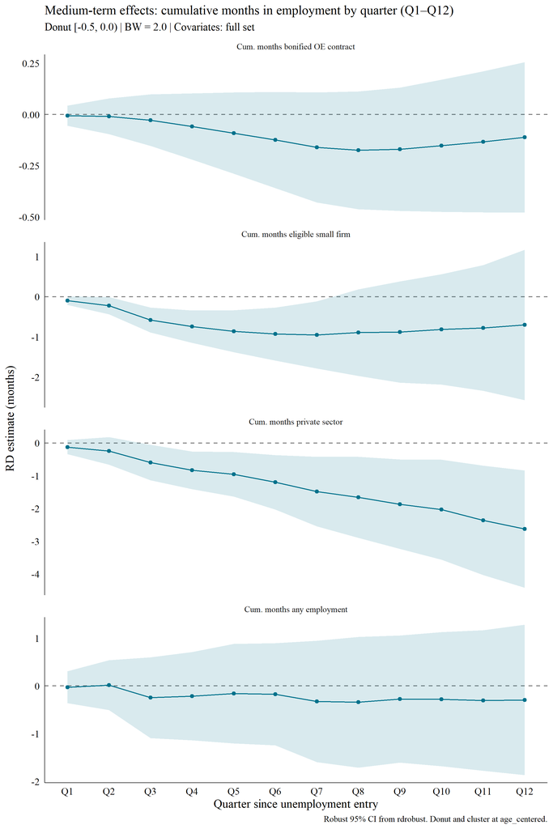

```r
.mt_labels <- c(
  cum_work               = "Cum. months any employment",
  cum_employee_priv      = "Cum. months private sector",
  cum_elig_cc1           = "Cum. months eligible small firm",
  cum_contract_potential = "Cum. months bonified OE contract"
)

ggplot(.mt_results, aes(x = quarter, y = est)) +
  geom_hline(yintercept = 0, linetype = "dashed", colour = "grey50") +
  geom_ribbon(aes(ymin = ci_lo, ymax = ci_hi), alpha = 0.15, fill = thesis_palette[1]) +
  geom_line(colour = thesis_palette[1]) +
  geom_point(colour = thesis_palette[1]) +
  facet_wrap(~ outcome, ncol = 1, scales = "free_y",
             labeller = labeller(outcome = .mt_labels)) +
  scale_x_continuous(breaks = .MT_QUARTERS, labels = paste0("Q", .MT_QUARTERS)) +
  labs(
    x       = "Quarter since unemployment entry",
    y       = "RD estimate (months)",
    title   = "Medium-term effects: cumulative months in employment by quarter (Q1–Q12)",
    subtitle = sprintf("Donut [%.1f, %.1f) | BW = %.1f | Covariates: full set",
                       RDD_DONUT_LO, RDD_DONUT_HI, RDD_DONUT_BW),
    caption = "Robust 95% CI from rdrobust. Donut and cluster at age_centered."
  ) +
  theme_thesis()
```

```r
# Clean up temporary columns added to rdd_sample
.tmp_cols <- unlist(lapply(names(.mt_outcomes), function(.nm)
  paste0(.nm, "_q", .MT_QUARTERS)))
.tmp_cols <- intersect(.tmp_cols, names(rdd_sample))
rdd_sample[, (.tmp_cols) := NULL]

rm(.mt_results, .mt_labels, .MT_QUARTERS, .MT_Q_ENDPOINTS, .mt_outcomes, .tmp_cols)
```

## 5.2 Exit rates from unemployment (conditional on being unemployed at start of quarter)

These outcomes are defined **conditional on still being unemployed at the first month of quarter q**, so they cannot enter the standard unconditional panel above. Quarters are defined relative to unemployment entry: Q1 = months 1–3, Q2 = months 4–6, Q3 = months 7–9, Q4 = months 10–12.

For each quarter q, we condition on `unemp_d == 1` at the first month of the quarter, then define exit as finding work in **any** of the three months of that quarter. Pooling three months per quarter triples the effective sample relative to the monthly analysis, tightening the confidence intervals.

- `exit_to_work_q`: = 1 if the worker finds any employment in at least one month of quarter q
- `exit_to_oe_q`: = 1 if the worker gets an OE contract in at least one month of quarter q
- `exit_to_temp_q`: = 1 if the worker gets a temporary contract in at least one month of quarter q

This uses the broader unemployment definition (UA + STU + LTU).

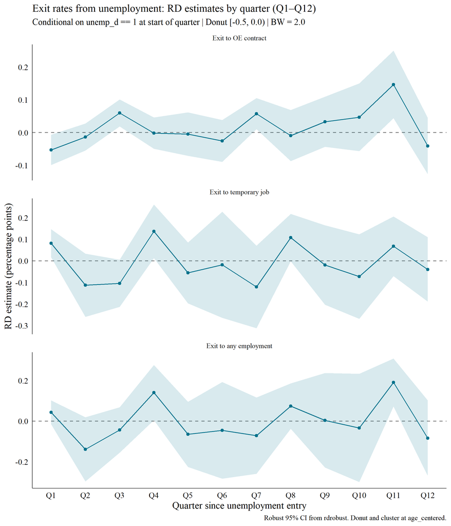

```r
.exit_labels_q <- c(
  exit_to_work_q = "Exit to any employment",
  exit_to_oe_q   = "Exit to OE contract",
  exit_to_temp_q = "Exit to temporary job"
)

ggplot(.exit_results_q, aes(x = quarter, y = est)) +
  geom_hline(yintercept = 0, linetype = "dashed", colour = "grey50") +
  geom_ribbon(aes(ymin = ci_lo, ymax = ci_hi), alpha = 0.15, fill = thesis_palette[1]) +
  geom_line(colour = thesis_palette[1]) +
  geom_point(colour = thesis_palette[1]) +
  facet_wrap(~ outcome, ncol = 1, scales = "free_y",
             labeller = labeller(outcome = .exit_labels_q)) +
  scale_x_continuous(breaks = .QUARTERS, labels = paste0("Q", .QUARTERS)) +
  labs(
    x       = "Quarter since unemployment entry",
    y       = "RD estimate (percentage points)",
    title   = "Exit rates from unemployment: RD estimates by quarter (Q1–Q12)",
    subtitle = sprintf("Conditional on unemp_d == 1 at start of quarter | Donut [%.1f, %.1f) | BW = %.1f",
                       RDD_DONUT_LO, RDD_DONUT_HI, RDD_DONUT_BW),
    caption = "Robust 95% CI from rdrobust. Donut and cluster at age_centered."
  ) +
  theme_thesis()
```

```r
rm(.exit_unemp_q, .exit_results_q, .exit_labels_q, .QUARTERS, .Q_START, .Q_MONTHS, .exit_outcomes_q)
```

# 6. Deep dive into take-up

The statistics of the SEPE show that between 2012 and 2018 there were 1.1 million “contratos de apoyos a los emprendedores”, which represents 20% of new OE contracts by firms with 50 workers. However, only 37% of them were subsidized. However, this does not tell us what the take-up is, because the workers may not have been eligible for the subsidy. Most of the subsidies occurred from 03-2012 to 03-2014 (later new general subsidies were available for small firms)

## 6.1 Take-up rate in the overall sample (2012-2018)

This sub-section starts from `spells_final_corrected` (the full spell-level dataset, not just RDD workers) to establish baseline take-up rates, replicating the structure of `check_bonification §6` but using `elig_spell_unemp_d` as the eligibility definition (previous spell = unemployment, matching our sample’s entry condition) and restricting to ages 26–34.

Over the whole period, the take-up rate is 12%, i.e. out of all new hire spells in an OE contract in small firms, only 12% get a subsidy.

```r
# Load eligible new-hire work spells in the reform period, ages 26-34.
# elig_spell_unemp_d = age < 30 + new hire + private firm ≤50 + OE contract + prev unemp spell.
# We load only columns needed and filter via Arrow to keep memory low.
.spells_elig <- arrow::open_dataset(
  file.path(PATHS$mcvl$clean, "spells_final.parquet")
) %>%
  dplyr::filter(
    spell_work_d     == 1L,
    spell_hire_cc1_d == 1L,
    spell_start_ym   >= 201202L,
    spell_start_ym   <= 201803L,
    spell_start_age  >= 26L,
    spell_start_age  <= 34L
  ) %>%
  dplyr::select(
    id, spell_start_dt, spell_start_ym, spell_start_age,
    contract_potential_d, contract_oe_d, spell_hire_cc1_d,
    elig_spell_d, elig_spell_unemp_d, elig_spell_UA_d,
    cc1_n_workers, cc2_priv_d, cc2_aff_start1_dt,
    pt_coef, spell_duration, female_d
  ) %>%
  dplyr::collect() %>%
  data.table::as.data.table()

cat(sprintf("Eligible-window spells loaded: %s spells | %s workers\n",
  format(nrow(.spells_elig),        big.mark = ","),
  format(uniqueN(.spells_elig$id),  big.mark = ",")))
```

```
Eligible-window spells loaded: 1,066,077 spells | 233,156 workers
```

```r
# Denominator: new hire OE spells in age 26-34, reform period.
# Three eligibility definitions — Broad (age + firm + OE), Unemp (+ prev unemp), UA (+ prev UA).
.elig_vars <- c("Broad" = "elig_spell_d", "Prev unemp" = "elig_spell_unemp_d", "Prev UA" = "elig_spell_UA_d")

purrr::imap_dfr(.elig_vars, \(var, label) {
  elig       <- as.logical(.spells_elig[[var]])
  bon        <- as.logical(.spells_elig$contract_potential_d)
  n_elig     <- sum(elig,       na.rm = TRUE)
  n_bon      <- sum(bon,        na.rm = TRUE)
  n_elig_bon <- sum(elig & bon, na.rm = TRUE)
  data.frame(
    Definition                      = label,
    `N eligible`                    = n_elig,
    `N bonified`                    = n_bon,
    `N eligible & bonified`         = n_elig_bon,
    `% eligible`                    = n_elig     / nrow(.spells_elig) * 100,
    `Take-up rate (among eligible)` = n_elig_bon / n_elig * 100,
    check.names = FALSE
  )
}) %>%
  knitr::kable(digits = 2,
    caption = "Take-up rate: new OE hires aged 26–34, reform period (Feb 2012–Mar 2018)")
```

Take-up rate: new OE hires aged 26–34, reform period (Feb 2012–Mar 2018)

| Definition | N eligible | N bonified | N eligible & bonified | % eligible | Take-up rate (among eligible) |
| --- | --- | --- | --- | --- | --- |
| Broad | 14075 | 2699 | 1089 | 1.32 | 7.74 |
| Prev unemp | 4565 | 2699 | 550 | 0.43 | 12.05 |
| Prev UA | 1689 | 2699 | 218 | 0.16 | 12.91 |

### Q1: Who are the bonified but not eligible?

```r
# Mutually exclusive buckets, priority order:
#   1. Age >= 30          — wrong age group (other programs, e.g. older worker bonifications)
#   2. Not a new hire     — modification/recall carrying over a prior bonification code
#   3. Public sector      — genuinely ineligible; reform was private-sector only
#   4. Missing firm size  — private, new hire, u30, but can't verify ≤50 threshold
#   5. Firm too large     — private, size observed, > 50 workers
# Note: contract type (OE) is already guaranteed by the spell filter above.

.spells_elig[contract_potential_d == 1L] %>%
  mutate(inelig_reason = case_when(
    spell_start_age > 30L                                          ~ "1. Age > 30",
    spell_hire_cc1_d == 0L                                          ~ "2. Not a new hire",
    cc2_priv_d == 0L                                                ~ "3. Public sector",
    is.na(cc1_n_workers)                                            ~ "4. Missing firm size",
    cc1_n_workers > 50L                                             ~ "5. Firm > 50",
    TRUE                                                            ~ "6. Eligible (broad)"
  )) %>%
  summarise(
    n                    = .N,
    `% of all bonified`  = .N / 2699 * 100,
    `Mean age at hire`   = mean(spell_start_age,  na.rm = TRUE),
    `Mean firm size`     = mean(cc1_n_workers,     na.rm = TRUE),
    `% Female`           = mean(female_d == 1L,    na.rm = TRUE) * 100,
    `Mean duration (d)`  = mean(spell_duration,    na.rm = TRUE),
    .by = inelig_reason
  ) %>%
  arrange(inelig_reason) %>%
  knitr::kable(digits = 1,
    caption = "Bonified spells: why ineligible? (mutually exclusive, priority order)")
```

Bonified spells: why ineligible? (mutually exclusive, priority order)

| inelig_reason | n | % of all bonified | Mean age at hire | Mean firm size | % Female | Mean duration (d) |
| --- | --- | --- | --- | --- | --- | --- |
| 1. Age > 30 | 372 | 13.8 | 32.5 | 7769.1 | 18.5 | 265.2 |
| 3. Public sector | 603 | 22.3 | 28.0 | 3727.0 | 45.1 | 389.2 |
| 4. Missing firm size | 385 | 14.3 | 27.9 | NaN | 37.7 | 309.7 |
| 5. Firm > 50 | 70 | 2.6 | 27.6 | 1886.8 | 50.0 | 532.3 |
| 6. Eligible (broad) | 1269 | 47.0 | 27.9 | 12.4 | 48.1 | 513.0 |

### Q2: How do people who are eligible but not bonified differ from those who are eligible and bonified?

```r
.spells_elig[elig_spell_unemp_d == 1L] %>%
  mutate(group = ifelse(
    contract_potential_d == 1L, "Eligible & Bonified", "Eligible & NOT bonified"
  )) %>%
  summarise(
    n                              = .N,
    `Mean age at hire`             = mean(spell_start_age, na.rm = TRUE),
    `% Female`                     = mean(female_d == 1L,  na.rm = TRUE) * 100,
    `Mean firm size (obs.)`        = mean(cc1_n_workers,   na.rm = TRUE),
    `% Missing firm size`          = mean(is.na(cc1_n_workers)) * 100,
    `% Part-time`                  = mean(pt_coef < 1,     na.rm = TRUE) * 100,
    `Mean spell duration (days)`   = mean(spell_duration,  na.rm = TRUE),
    .by = group
  ) %>%
  knitr::kable(digits = 1,
    caption = "Eligible new OE hires aged 26–34: bonified vs. non-bonified")
```

Eligible new OE hires aged 26–34: bonified vs. non-bonified

| group | n | Mean age at hire | % Female | Mean firm size (obs.) | % Missing firm size | % Part-time | Mean spell duration (days) |
| --- | --- | --- | --- | --- | --- | --- | --- |
| Eligible & Bonified | 550 | 27.5 | 49.8 | 12.6 | 0 | 15.8 | 503.8 |
| Eligible & NOT bonified | 4015 | 27.5 | 45.7 | 14.4 | 0 | 26.9 | 440.0 |

```r
rm(.spells_elig, .elig_vars)
```

## 6.2 Take-up rate in the RDD sample

```r
.spells_rdd <- arrow::open_dataset(
  file.path(PATHS$mcvl$clean, "spells_final.parquet")
) %>%
  dplyr::filter(
    id           %in% rdd_sample$id,
    spell_work_d  == 1L,
    spell_hire_cc1_d == 1L,
    spell_start_ym   >= RDD_ENTRY_LO,
    spell_start_ym   <= 201403L        # latest entry (201303) + 12m
  ) %>%
  dplyr::select(
    id, spell_start_ym, spell_start_age,
    contract_oe_d, contract_potential_d, spell_hire_cc1_d,
    elig_spell_d, elig_spell_unemp_d, elig_spell_UA_d,
    cc1_n_workers, cc2_priv_d, cc2_aff_start1_dt,
    pt_coef, spell_duration, female_d, spell_start_dt
  ) %>%
  dplyr::collect() %>%
  data.table::as.data.table()

# Keep only hires that fall within each worker's personal 12-month window after entry.
.spells_rdd[rdd_sample, on = "id", ref_entry_ym := i.ref_entry_ym]
.spells_rdd[, entry_plus_12 := add_months_ym(ref_entry_ym, 12L)]
.spells_rdd <- .spells_rdd[
  spell_start_ym > ref_entry_ym & spell_start_ym <= entry_plus_12
]
.spells_rdd[, entry_plus_12 := NULL]

# Restrict to OE contracts (reform requires OE)
.spells_rdd_oe <- .spells_rdd[contract_oe_d == 1L]

cat(sprintf("OE new-hire spells in m1-12 for RDD workers: %s spells | %s workers\n",
  format(nrow(.spells_rdd_oe),        big.mark = ","),
  format(uniqueN(.spells_rdd_oe$id),  big.mark = ",")))
```

```
OE new-hire spells in m1-12 for RDD workers: 4,546 spells | 3,845 workers
```

```r
.elig_vars_rdd <- c("Broad" = "elig_spell_d", "Prev unemp" = "elig_spell_unemp_d", "Prev UA" = "elig_spell_UA_d")

purrr::imap_dfr(.elig_vars_rdd, \(var, label) {
  elig       <- as.logical(.spells_rdd_oe[[var]])
  bon        <- as.logical(.spells_rdd_oe$contract_potential_d)
  n_elig     <- sum(elig,       na.rm = TRUE)
  n_bon      <- sum(bon,        na.rm = TRUE)
  n_elig_bon <- sum(elig & bon, na.rm = TRUE)
  data.frame(
    Definition                      = label,
    `N eligible`                    = n_elig,
    `N bonified`                    = n_bon,
    `N eligible & bonified`         = n_elig_bon,
    `% eligible`                    = n_elig     / nrow(.spells_rdd_oe) * 100,
    `Take-up rate (among eligible)` = n_elig_bon / n_elig * 100,
    check.names = FALSE
  )
}) %>%
  knitr::kable(digits = 2,
    caption = "Take-up rate: OE new hires in m1–12, RDD sample workers")
```

Take-up rate: OE new hires in m1–12, RDD sample workers

| Definition | N eligible | N bonified | N eligible & bonified | % eligible | Take-up rate (among eligible) |
| --- | --- | --- | --- | --- | --- |
| Broad | 396 | 125 | 66 | 8.71 | 16.67 |
| Prev unemp | 295 | 125 | 57 | 6.49 | 19.32 |
| Prev UA | 167 | 125 | 32 | 3.67 | 19.16 |

### Q1: Who are the bonified but not eligible?

Note: “2. Not a new hire” is absent by construction — `.spells_rdd_oe` was loaded with `spell_hire_cc1_d == 1L`. The public sector bucket reflects semi-public employers using the same OE contract codes under separate collective agreements — genuinely ineligible for the reform.

```r
.spells_rdd_oe[contract_potential_d == 1L] %>%
  mutate(inelig_reason = case_when(
    spell_start_age > 30L                                         ~ "1. Age > 30",
    cc2_priv_d == 0L                                              ~ "2. Public sector",
    is.na(cc1_n_workers)                                          ~ "3. Missing firm size",
    cc1_n_workers > 50L                                           ~ "4. Firm > 50",
    TRUE                                                          ~ "5. Eligible (broad)"
  )) %>%
  summarise(
    n                   = .N,
    `% of all bonified` = .N / sum(.spells_rdd_oe$contract_potential_d == 1L, na.rm = TRUE) * 100,
    `Mean age at hire`  = mean(spell_start_age, na.rm = TRUE),
    `Mean firm size`    = mean(cc1_n_workers,   na.rm = TRUE),
    .by = inelig_reason
  ) %>%
  arrange(inelig_reason) %>%
  knitr::kable(digits = 1,
    caption = "Bonified OE new hires in RDD sample: why ineligible?")
```

Bonified OE new hires in RDD sample: why ineligible?

| inelig_reason | n | % of all bonified | Mean age at hire | Mean firm size |
| --- | --- | --- | --- | --- |
| 1. Age > 30 | 3 | 2.4 | 31.0 | 8.5 |
| 2. Public sector | 26 | 20.8 | 28.5 | 621.7 |
| 3. Missing firm size | 13 | 10.4 | 28.4 | NaN |
| 4. Firm > 50 | 2 | 1.6 | 28.5 | 105.5 |
| 5. Eligible (broad) | 81 | 64.8 | 28.5 | 11.9 |

### Q2: How do people who are eligible but not bonified differ from those who are eligible and bonified?

```r
.spells_rdd_oe[elig_spell_unemp_d == 1L] %>%
  mutate(group = ifelse(
    contract_potential_d == 1L, "Eligible & Bonified", "Eligible & NOT bonified"
  )) %>%
  summarise(
    n                            = .N,
    `Mean age at hire`           = mean(spell_start_age, na.rm = TRUE),
    `% Female`                   = mean(female_d == 1L,  na.rm = TRUE) * 100,
    `Mean firm size (obs.)`      = mean(cc1_n_workers,   na.rm = TRUE),
    `% Missing firm size`        = mean(is.na(cc1_n_workers)) * 100,
    `% Part-time`                = mean(pt_coef < 1,     na.rm = TRUE) * 100,
    `Mean spell duration (days)` = mean(spell_duration,  na.rm = TRUE),
    .by = group
  ) %>%
  knitr::kable(digits = 1,
    caption = "Eligible OE new hires in RDD sample: bonified vs. non-bonified")
```

Eligible OE new hires in RDD sample: bonified vs. non-bonified

| group | n | Mean age at hire | % Female | Mean firm size (obs.) | % Missing firm size | % Part-time | Mean spell duration (days) |
| --- | --- | --- | --- | --- | --- | --- | --- |
| Eligible & Bonified | 57 | 28.2 | 40.4 | 12.6 | 0 | 0.0 | 541.7 |
| Eligible & NOT bonified | 238 | 28.2 | 50.8 | 16.5 | 0 | 0.4 | 399.1 |

```r
rm(.spells_rdd, .spells_rdd_oe, .elig_vars_rdd)
```

**Implication for ITT vs. LATE conversion.** The RDD estimates an ITT — the reduced-form effect on all workers who crossed the age-31 cutoff. The natural first stage for a Wald/IV scaling is the jump in take-up probability at the cutoff, estimated by the same RDD on `within_12m_contract_potential_d`. From the RDD results in Section 4: **est = −0.003, p = 0.152** — no detectable discontinuity in take-up at the cutoff.

This is consistent with the spell-level rates here. The take-up rate conditional on finding an eligible OE job (~20%) looks large, but that denominator is highly selected: only workers who found a new OE hire at a private firm with ≤50 workers. Scaled to *all* entrants, the unconditional rate is ~1% below 31 vs ~0.18% above 31 — a ~0.8pp gap that the RDD cannot reliably detect. Three implications:

1. **No well-defined LATE**: with a near-zero first stage, the Wald ratio is undefined (or very noisy). The ITT is the most credible estimand.
2. **ITT ≈ 0 is consistent with low take-up**: even if the reform had large effects on compliers, ITT ≈ first stage × LATE ≈ 0.008 × LATE, so the LATE could be large but the ITT would still be close to zero.
3. **Power problem**: the low take-up rate means the reform affected very few workers near the cutoff, making it hard to detect effects in the ITT even if they exist for the small complier group.

## 6.3 Unemployment duration before take-up

We join the spell-level dataset to extract the unemployment spell that each worker was in at their entry month (`ref_entry_ym`). The spell’s `spell_duration` (in days) measures how long the unemployment episode lasted before they eventually found a job (or the spell ended for another reason).

```r
# Load unemployment spells for RDD sample workers only.
# We want the spell that was active at ref_entry_ym:
#   spell_start_ym <= ref_entry_ym AND spell_end_ym >= ref_entry_ym
# and that is an unemployment spell (spell_unemp_d == 1).
.unemp_spells <- arrow::open_dataset(
  file.path(PATHS$mcvl$clean, "mcvl_spells_extended.parquet")
) %>%
  dplyr::filter(id %in% rdd_sample$id, spell_unemp_d == 1L) %>%
  dplyr::select(
    id, spell_start_dt, spell_end_dt, spell_duration,
    spell_UA_d, spell_LTU_d, spell_STU_d
  ) %>%
  dplyr::collect() %>%
  data.table::as.data.table()

# Convert ref_entry_ym to a date range for matching:
# ref_entry_ym = YYYYMM; spell contains entry month if
# spell_start_dt <= last day of entry month AND spell_end_dt >= first day of entry month.
.unemp_spells[rdd_sample, on = "id", ref_entry_ym := i.ref_entry_ym]

.unemp_spells[, entry_month_start := as.IDate(
  paste0(ref_entry_ym %/% 100L, "-",
         formatC(ref_entry_ym %% 100L, width = 2, flag = "0"), "-01")
)]
.unemp_spells[, entry_month_end := entry_month_start + 27L]   # safe approx (ends within the month)

# Keep only the spell active during the entry month (the spell the worker was in when we observe them)
.entry_spells <- .unemp_spells[
  spell_start_dt <= entry_month_end & spell_end_dt >= entry_month_start
]

# If a worker has multiple matching spells (rare edge case), keep the longest
.entry_spells <- .entry_spells[
  .entry_spells[, .I[which.max(spell_duration)], by = id]$V1
]

cat(sprintf(
  "Matched %s RDD workers to an unemployment spell at entry (out of %s total)\n",
  format(uniqueN(.entry_spells$id), big.mark = ","),
  format(nrow(rdd_sample),          big.mark = ",")
))
```

```
Matched 38,044 RDD workers to an unemployment spell at entry (out of 39,228 total)
```

```r
# Join spell_duration (and type flags) back to rdd_sample
rdd_sample[.entry_spells, on = "id", `:=`(
  entry_unemp_dur_days = i.spell_duration,
  entry_spell_UA_d     = i.spell_UA_d,
  entry_spell_LTU_d    = i.spell_LTU_d,
  entry_spell_STU_d    = i.spell_STU_d
)]

rm(.unemp_spells, .entry_spells)

# Summary: unemployment duration by take-up status
rdd_sample[!is.na(within_12m_contract_potential_d) & !is.na(entry_unemp_dur_days)] %>%
  mutate(got_subsidy = factor(within_12m_contract_potential_d, 0:1, c("No subsidy", "Got subsidy"))) %>%
  summarise(
    n                               = .N,
    `Mean unemp. duration (days)`   = as.numeric(mean(entry_unemp_dur_days)),
    `Median unemp. duration (days)` = as.numeric(median(entry_unemp_dur_days)),
    `P25 (days)`                    = as.numeric(quantile(entry_unemp_dur_days, 0.25)),
    `P75 (days)`                    = as.numeric(quantile(entry_unemp_dur_days, 0.75)),
    `% UA spell`                    = mean(entry_spell_UA_d,  na.rm = TRUE) * 100,
    `% LTU spell`                   = mean(entry_spell_LTU_d, na.rm = TRUE) * 100,
    .by = got_subsidy
  ) %>%
  arrange(got_subsidy) %>%
  knitr::kable(digits = 1)
```

| got_subsidy | n | Mean unemp. duration (days) | Median unemp. duration (days) | P25 (days) | P75 (days) | % UA spell | % LTU spell |
| --- | --- | --- | --- | --- | --- | --- | --- |
| No subsidy | 37814 | 172.3 | 120 | 55.0 | 210.0 | 83.1 | 1.3 |
| Got subsidy | 230 | 157.3 | 106 | 46.2 | 183.8 | 85.7 | 3.0 |

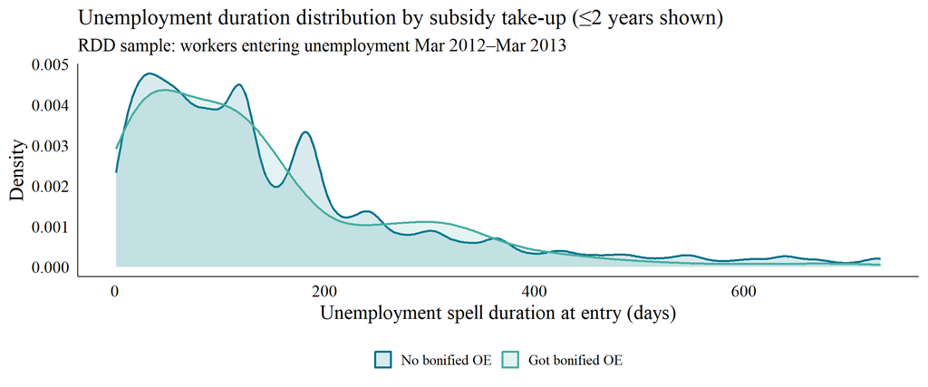

```r
# Distribution of unemployment duration by take-up status
rdd_sample[!is.na(within_12m_contract_potential_d) & !is.na(entry_unemp_dur_days) &
           entry_unemp_dur_days <= 730L] %>%
  mutate(got_subsidy = factor(within_12m_contract_potential_d, 0:1,
                              c("No bonified OE", "Got bonified OE"))) %>%
  ggplot(aes(x = entry_unemp_dur_days, colour = got_subsidy, fill = got_subsidy)) +
  geom_density(alpha = 0.15, linewidth = 1) +
  scale_colour_manual(values = setNames(thesis_palette[1:2], c("No bonified OE", "Got bonified OE"))) +
  scale_fill_manual( values = setNames(thesis_palette[1:2], c("No bonified OE", "Got bonified OE"))) +
  labs(
    x = "Unemployment spell duration at entry (days)",
    y = "Density",
    colour = NULL, fill = NULL,
    title = "Unemployment duration distribution by subsidy take-up (≤2 years shown)",
    subtitle = "RDD sample: workers entering unemployment Mar 2012–Mar 2013"
  ) +
  theme_thesis() +
  theme(legend.position = "bottom")
```

## 6.4 Age distribution at take-up

We already have `age_frac` = age in fractional years at unemployment entry. For workers who took up, we additionally compute their age at the moment of hire into the bonified job, using the first month in m1–m12 where `contract_potential_d == 1`.

```r
# within_12m_contract_potential_d is built from contract_potential_d_m{h} columns
# (main panel spine, not the wage spine). Use those same columns for hire_horizon
# so the N matches exactly.
# within_12m_contract_potential_d uses pmax over m0:12 — include m0 here too.
.cp_cols <- intersect(paste0("contract_potential_d_m", 0:12), names(rdd_sample))
# Extract the month number from each column name (0, 1, ..., 12)
.cp_months <- as.integer(gsub(".*_m", "", .cp_cols))
cat("contract_potential_d columns found:", length(.cp_cols),
    "| months:", paste(.cp_months, collapse = " "), "\n")
```

```
contract_potential_d columns found: 13 | months: 0 1 2 3 4 5 6 7 8 9 10 11 12
```

```r
rdd_sample[, hire_horizon := {
  .mat <- as.matrix(.SD)
  vapply(seq_len(nrow(.mat)), function(i) {
    idx <- which(.mat[i, ] == 1L)
    if (length(idx) == 0L) NA_integer_ else .cp_months[idx[[1L]]]
  }, integer(1L))
}, .SDcols = .cp_cols]

# Fractional age at hire = entry age + months elapsed / 12
rdd_sample[, age_at_hire := fifelse(!is.na(hire_horizon), age_frac + hire_horizon / 12, NA_real_)]

cat(sprintf("Takers (within_12m_contract_potential_d == 1):  %s\n",
  format(sum(rdd_sample$within_12m_contract_potential_d == 1L, na.rm = TRUE), big.mark = ",")))
```

```
Takers (within_12m_contract_potential_d == 1):  237
```

```r
cat(sprintf("Of which age_at_hire not NA (via panel months): %s\n",
  format(sum(!is.na(rdd_sample$age_at_hire)), big.mark = ",")))
```

```
Of which age_at_hire not NA (via panel months): 237
```

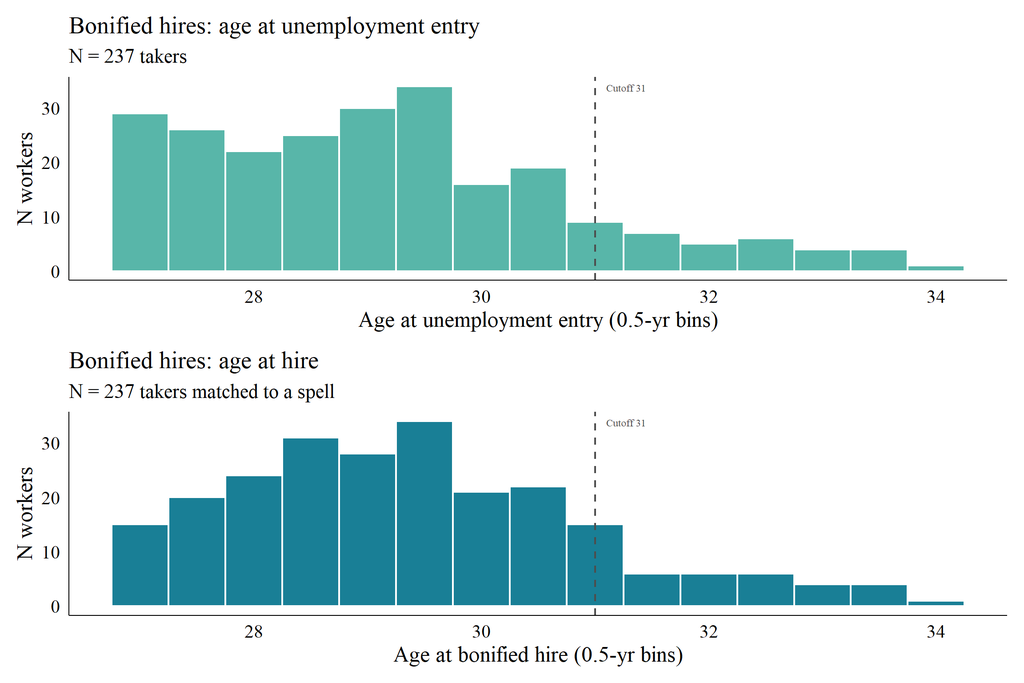

```r
.n_bon <- sum(rdd_sample$within_12m_contract_potential_d == 1L, na.rm = TRUE)

# Panel 1: age at unemployment entry for bonified takers
.age_entry_bon <- rdd_sample[within_12m_contract_potential_d == 1L & !is.na(age_frac), .(age_frac)]

.p1 <- ggplot(.age_entry_bon, aes(x = age_frac)) +
  geom_histogram(binwidth = 0.5, fill = thesis_palette[2], colour = "white", alpha = 0.9) +
  geom_vline(xintercept = 31, linetype = "dashed", colour = "grey30") +
  annotate("text", x = 31.1, y = Inf, vjust = 2, hjust = 0, label = "Cutoff 31",
           size = 3, family = "serif", colour = "grey30") +
  labs(x = "Age at unemployment entry (0.5-yr bins)", y = "N workers",
       title = "Bonified hires: age at unemployment entry",
       subtitle = paste0("N = ", format(.n_bon, big.mark = ","), " takers")) +
  theme_thesis()

# Panel 2: age at bonified hire (from spell data, same N)
.age_hire <- rdd_sample[!is.na(age_at_hire), .(age_at_hire)]

.p2 <- ggplot(.age_hire, aes(x = age_at_hire)) +
  geom_histogram(binwidth = 0.5, fill = thesis_palette[1], colour = "white", alpha = 0.9) +
  geom_vline(xintercept = 31, linetype = "dashed", colour = "grey30") +
  annotate("text", x = 31.1, y = Inf, vjust = 2, hjust = 0, label = "Cutoff 31",
           size = 3, family = "serif", colour = "grey30") +
  labs(x = "Age at bonified hire (0.5-yr bins)", y = "N workers",
       title = "Bonified hires: age at hire",
       subtitle = paste0("N = ", format(nrow(.age_hire), big.mark = ","),
                         " takers matched to a spell")) +
  theme_thesis()

patchwork::wrap_plots(.p1, .p2, ncol = 1)
```

```r
rm(.age_entry_bon, .age_hire, .p1, .p2, .n_bon)
```

```r
# Summary table: age at entry vs. age at hire for subsidy takers
rdd_sample[!is.na(hire_horizon)] %>%
  summarise(
    n                          = .N,
    `Mean age at unemp. entry` = mean(age_frac,     na.rm = TRUE),
    `Mean age at hire`         = mean(age_at_hire,  na.rm = TRUE),
    `Median age at hire`       = median(age_at_hire, na.rm = TRUE),
    `% hired before age 31`    = mean(age_at_hire < 31, na.rm = TRUE) * 100,
    `Mean months to hire`      = mean(hire_horizon, na.rm = TRUE),
    `Median months to hire`    = median(hire_horizon)
  ) %>%
  knitr::kable(digits = 2,
    caption = "Subsidy takers: age profile (workers with bonified OE in m1–m12)")
```

Subsidy takers: age profile (workers with bonified OE in m1–m12)

| n | Mean age at unemp. entry | Mean age at hire | Median age at hire | % hired before age 31 | Mean months to hire | Median months to hire |
| --- | --- | --- | --- | --- | --- | --- |
| 237 | 29.21 | 29.43 | 29.33 | 86.92 | 2.71 | 1 |